# Análise Exploratória de Dados

Análise Exploratória Gráfica

Autor

Mateus Rezende Bispo

Data de Publicação

4 de junho de 2025

# 1 Visualização de Dados e o Pacote ggplot2

## 1.1 O Quarteto de Anscombe

```r
# Carregando o conjunto de dados Anscombe (built-in no R)
data(anscombe)
head(anscombe)
```

```
  x1 x2 x3 x4   y1   y2    y3   y4
1 10 10 10  8 8.04 9.14  7.46 6.58
2  8  8  8  8 6.95 8.14  6.77 5.76
3 13 13 13  8 7.58 8.74 12.74 7.71
4  9  9  9  8 8.81 8.77  7.11 8.84
5 11 11 11  8 8.33 9.26  7.81 8.47
6 14 14 14  8 9.96 8.10  8.84 7.04
```

- **Quatro pares de variáveis:** (x1,y1), (x2,y2), (x3,y3), (x4,y4)
- **Propriedades:** As médias, desvios-padrão, assimetria, curtose e outras medidas são praticamente iguais!

## 1.2 Um Gráfico Exploratório

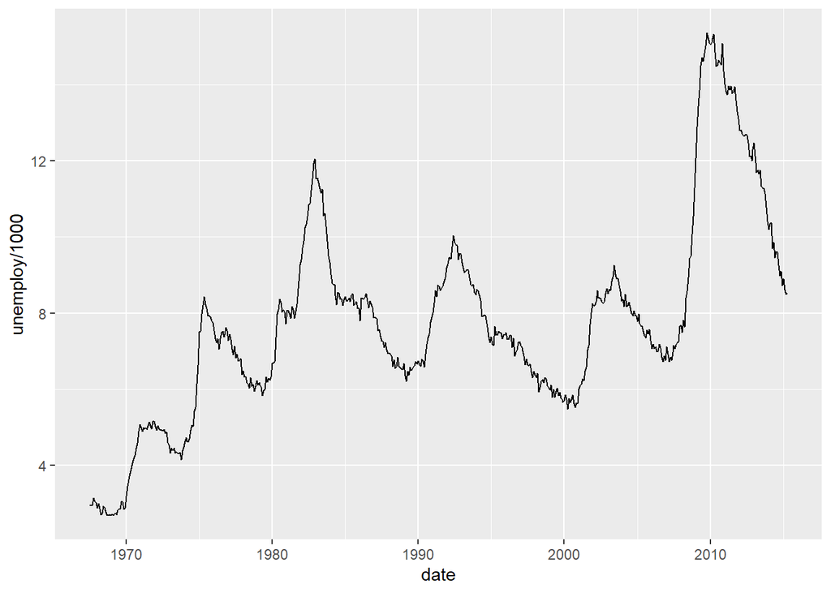

Gráfico de linha exploratório

```r
# a função ggplot() cria um sistema de coordenadas vazio
ggplot(data = economics,
       mapping = aes(x = date, y = unemploy/1000)) +
  # adiciona um gráfico de linha
  geom_line()
```

## 1.3 Um Gráfico para Publicação

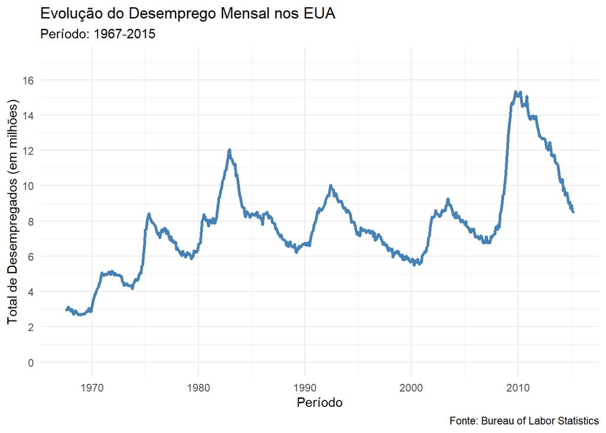

Evolução do Desemprego nos EUA (1967-2015)

```r
# salva o gráfico em um objeto
grafico_desemprego_eua <-
# a função ggplot() cria um sistema de coordenadas vazio
ggplot(data = economics,
       mapping = aes(x = date, y = unemploy/1000)) +
  # adiciona um gráfico de linha
  geom_line(color = "steelblue", size = 1.2) +
  # adiciona zero no eixo Y
  scale_y_continuous(limits = c(0, 17), breaks = seq(0, 16, 2)) +
  # adiciona título, subtítulo, rótulos dos eixos e fonte
  labs(title = "Evolução do Desemprego Mensal nos EUA",
       subtitle = "Período: 1967-2015",
       x = "Período",
       y = "Total de Desempregados (em milhões)",
       caption = "Fonte: Bureau of Labor Statistics") +
  # define o tema do gráfico
  theme_minimal()

# exibe o gráfico
grafico_desemprego_eua
```

# 2 Gráficos para Visualizar a Distribuição de Variáveis Numéricas

## 2.1 O que são?

São características observáveis nos gráficos da **distribuição** de variáveis numéricas:

- **Simetria/Assimetria**: A distribuição é simétrica? Assimétrica à esquerda? ou assimétrica à direita?.
- **Modalidade**: A distribuição possui um ou dois ou mais picos (ou modas)?
- **Valores Extremos**: Há um ou mais valores muito distantes da maioria dos dados?
- **Variação**: Qual variável apresenta maior variação? Faz sentido somente ao comparar mais de uma variável.
- **Gaps**: Há intervalos de valores que não contém dados?
- **Erros**: Há valores fora do intervalo factível?

## 2.2 Histograma

### 2.2.1 O que é um histograma?

- Um histograma é uma gráfico para visualizar a distribuição de uma variável aleatória numérica.
- Ele é construído dividindo o intervalo total dos dados em uma série de intervalos (*bins*), e o total de dados em cada intervalo é representada pela altura de cada barra.
- Assim, cada barra do histograma representa a **frequência** (número de ocorrências) dos dados dentro de um determinado intervalo de valores.

## 2.3 Histograma exploratório

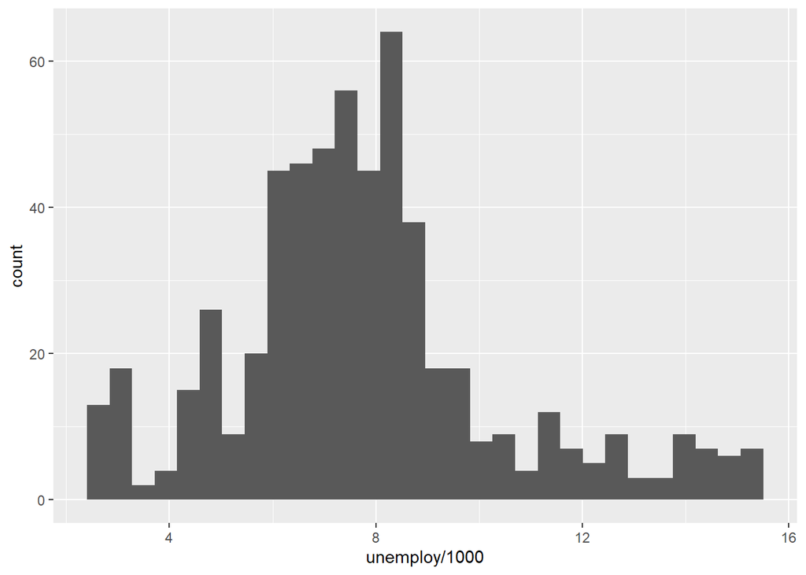

```r
# a função ggplot() cria um sistema de coordenadas vazio
ggplot(data = economics,
       mapping = aes(x = unemploy/1000)) +
  # adiciona um histograma
  geom_histogram()
```

## 2.4 Histograma exploratório

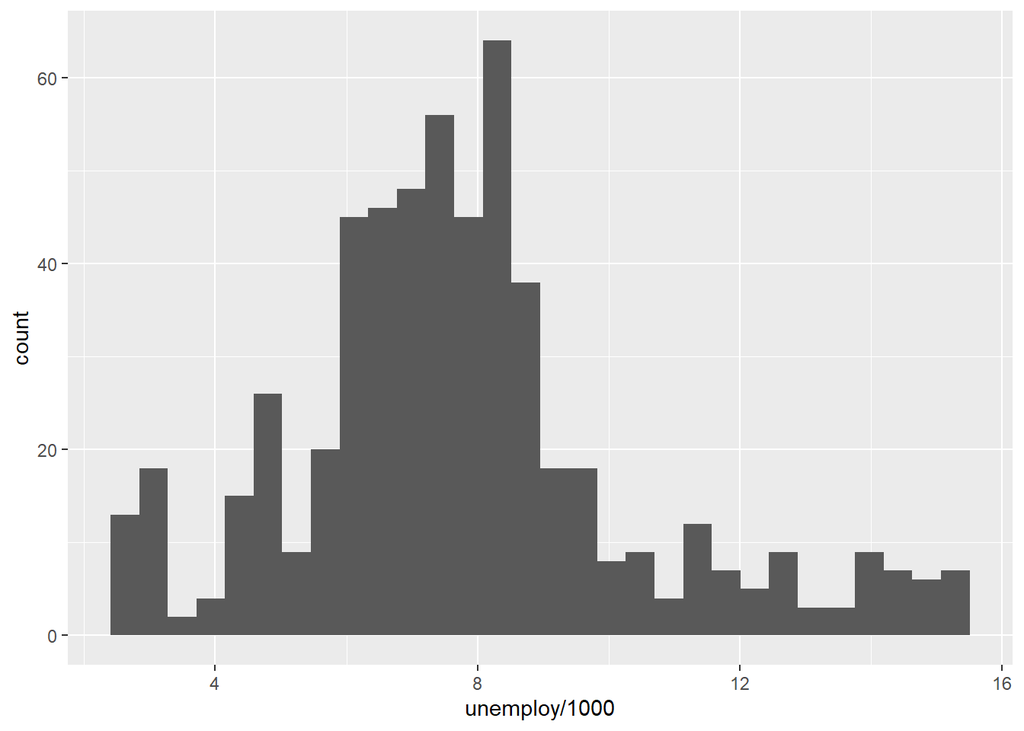

Histograma da Distribuição do Desemprego nos EUA (1967-2015)

```r
# a função ggplot() cria um sistema de coordenadas vazio
ggplot(data = economics,
       mapping = aes(x = unemploy/1000)) +
  # adiciona um histograma
  geom_histogram()
```

## 2.5 Como Escolher o Número de Intervalos?

### 2.5.1 Fórmula da Regra de Sturges

$$k = 1 + \log_2(n)$$

Onde **k** representa o número de intervalos recomendado e **n** o tamanho da amostra.

Aplicação aos Dados de Desemprego:

```r
# Calcula o tamanho da amostra
n <- length(economics$unemploy)
n
```

```
[1] 574
```

```r
# Aplicar a regra de Sturges
k <- ceiling(1 + log2(n))
k
```

```
[1] 11
```

**Resultado**: Para 574 observações, a regra recomenda **11 classes**.

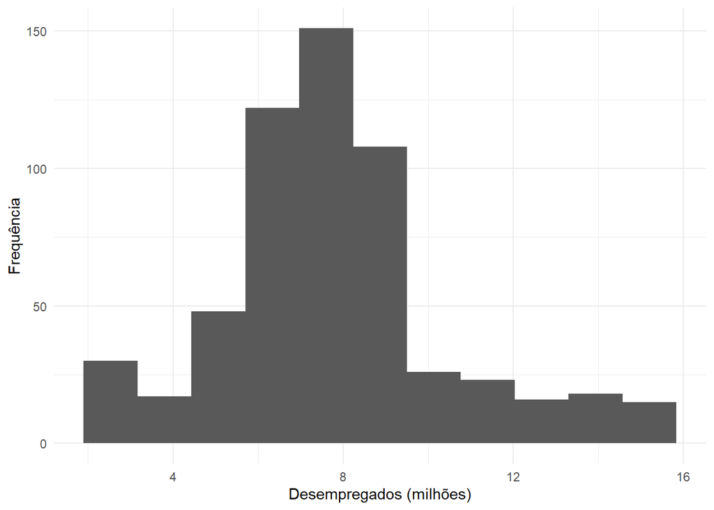

```r
# Usar o número de classes calculado no histograma
ggplot(data = economics,
       mapping = aes(x = unemploy/1000)) +
  geom_histogram(bins = 11) +
  labs(x = "Desempregados (milhões)",
       y = "Frequência") +
  theme_minimal()
```

## 2.7 Histogram para Publicação

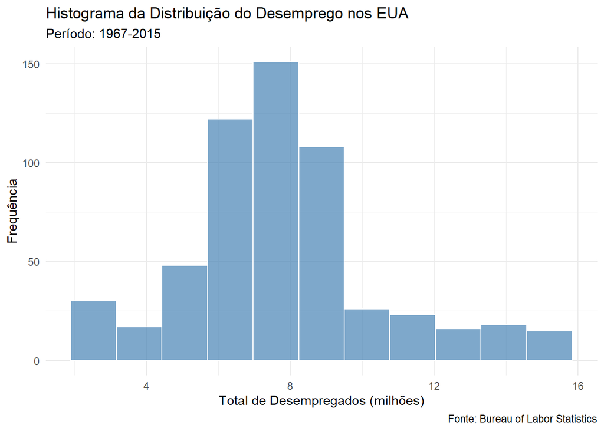

```r
# Usar o número de classes calculado no histograma
ggplot(
  data = economics,
  mapping = aes(x = unemploy / 1000)
) +
  geom_histogram(bins = 11, fill = "steelblue", alpha = 0.7, color = "white") +
  labs(
    title = "Histograma da Distribuição do Desemprego nos EUA",
    subtitle = "Período: 1967-2015",
    x = "Total de Desempregados (milhões)",
    y = "Frequência",
    caption = "Fonte: Bureau of Labor Statistics"
  ) +
  theme_minimal()
```

## 2.8 Estatísticas Descritivas

```r
# calcula estatísticas descritivas
economics %>%
  summarise(
    media = mean(unemploy, na.rm = TRUE),
    mediana = median(unemploy, na.rm = TRUE),
    desvio_padrao = sd(unemploy, na.rm = TRUE),
    assimetria = fBasics::skewness(unemploy, na.rm = TRUE),
    curtose = fBasics::kurtosis(unemploy, na.rm = TRUE)
  )
```

```
# A tibble: 1 × 5
  media mediana desvio_padrao assimetria curtose
  <dbl>   <dbl>         <dbl>      <dbl>   <dbl>
1 7771.    7494         2642.      0.697   0.795
```

## 2.9 Uma Análise Plausível

O histograma apresenta distribuição unimodal com assimetria positiva entre fraca e moderada (coeficiente de assimetria 0,697), indicando que houve períodos ocasionais de alto desemprego. A concentração principal ocorreu entre 5 e 10 milhões de desempregados aproximadamente

A distribuição unimodal com alguma assimetria positiva indica que a maioria das observações concentra-se em níveis de desemprego moderados, enquanto episódios de alto desemprego ocorreram com menor frequências, assim, possivelmente a assimetria observada captura recessivos econômicos ou eventos excepcionais ocorridos no período analisado.

## 2.10 Densidade Empírica (ou Kernel da Densidade)

### 2.10.1 O que é um gráfico de densidade empírica?

- Um gráfico da densidade empírica dos dados é uma representação visual que estima a função densidade de probabilidade de uma variável numérica contínua.
- Diferente do histograma, que agrupa os dados em intervalos mostra a frequência absoluta de cada intervalo, o gráfico de densidade suaviza os dados para formar uma curva contínua.
- Este tipo de gráfico é gerado através de um processo conhecido como  
  **estimativa do kernel da densidade**.
- A ideia básica por trás da estimação do kernel de uma densidade é suavizar os pontos de dados individuais em toda a região do espaço de dados, de forma a obter uma estimativa contínua para a função de probabilidade.
- Isso é feito utilizando uma função conhecida como “**kernel**”, que distribui o peso dos pontos de dados ao longo de um intervalo de valores, com o maior peso geralmente no centro e diminuindo conforme se afasta do ponto central.

Um dos kernels mais comuns é o kernel gaussiano:

$$K(x) = \frac{1}{\sqrt{2 \pi}} \exp \left(-\frac{x^2}{2}\right)$$

- A estimativa da densidade $f(x)$ em um ponto $x$ é dada por:

$$f(x) = \frac{1}{nh}\sum_{i=1}^{n} K\left(\frac{x - x_i}{h}\right)$$

sendo:

- $n$ o número de pontos de dados,
- $x_i$ são os dados,
- $K$ é a função do kernel,
- $h$ é a largura da banda ou intervalo (*binwidth*), um parâmetro crítico que controla o grau de suavização da estimativa da densidade.

## 2.11 Densidade Exploratória

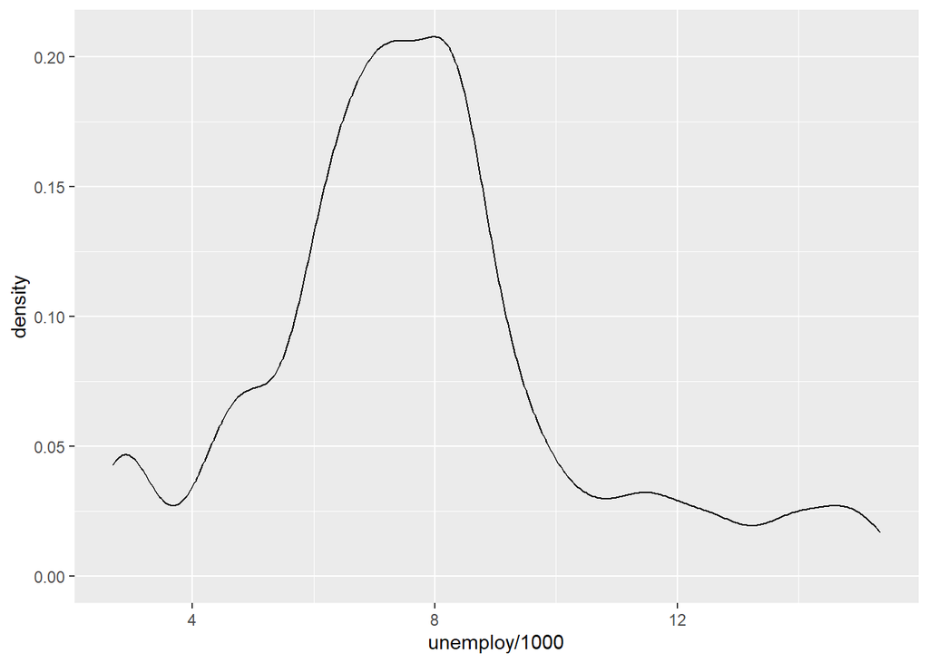

```r
# salva o gráfico em um objeto
densidade_exploratoria <-
  # ggplot() cria um sistema de coordenadas vazio
  ggplot(economics, aes(x = unemploy/1000)) +
  # adiciona um gráfico de densidade
  geom_density()

# exibe o gráfico
densidade_exploratoria
```

## 2.12 Densidade para Publicação

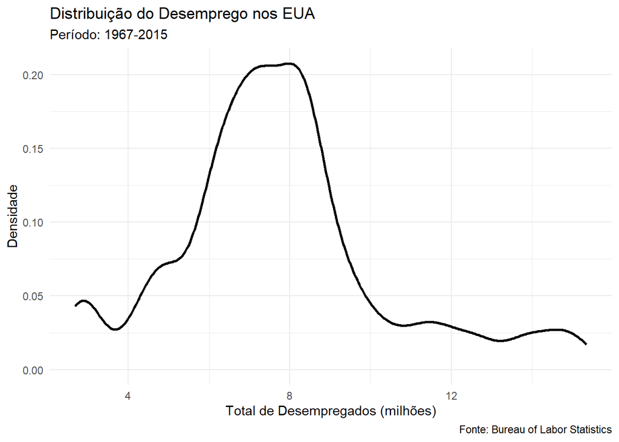

```r
# salva o gráfico em um objeto
densidade_publicacao <-
  # ggplot() cria um sistema de coordenadas vazio
  ggplot(economics, aes(x = unemploy/1000)) +
  # adiciona um gráfico de densidade
  # size define a espessura da linha
  geom_density(size = 1) +
  # adiciona título, subtítulo, rótulos dos eixos e fonte
  labs(
    title = "Distribuição do Desemprego nos EUA",
    subtitle = "Período: 1967-2015",
    x = "Total de Desempregados (milhões)",
    y = "Densidade",
    caption = "Fonte: Bureau of Labor Statistics"
  )  +
  # define o tema do gráfico
  theme_minimal()

# exibe o gráfico
densidade_publicacao
```

## 2.13 Histograma com densidade empírica sobreposta

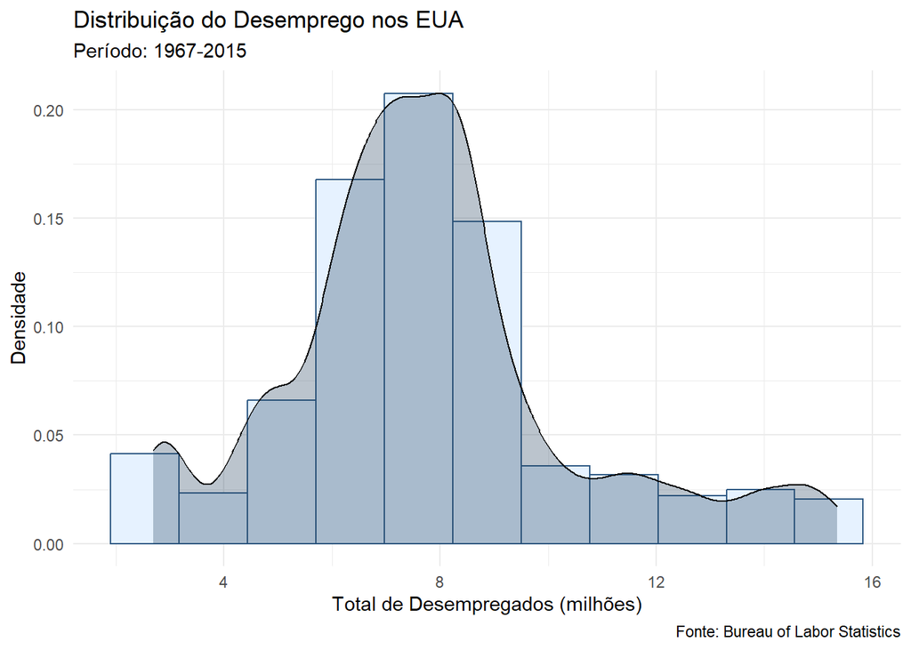

```r
# salva o gráfico em um objeto
histograma_densidade <-
  # ggplot() cria um sistema de coordenadas vazio
  ggplot(economics, aes(x = unemploy/1000))  +
  # adiciona um histograma
  geom_histogram(
    aes(y = after_stat(density)), # normaliza o histograma
    bins = 11,
    fill = "#E6F2FF",     # azul muito claro para as barras
    color = "#2E5984"     # azul escuro para borda das barras
  ) +
  # adiciona uma densidade empírica
  geom_density(
    alpha = .3,       # transparência
    fill = "#1B3A57"  # azul navy para a densidade
  ) +
  # adiciona título, subtítulo, rótulos dos eixos e fonte
  labs(
    title = "Distribuição do Desemprego nos EUA",
    subtitle = "Período: 1967-2015",
    x = "Total de Desempregados (milhões)",
    y = "Densidade",
    caption = "Fonte: Bureau of Labor Statistics"
  ) +
  # define o tema do gráfico
  theme_minimal()

histograma_densidade
```

## 2.15 Boxplot Exploratório

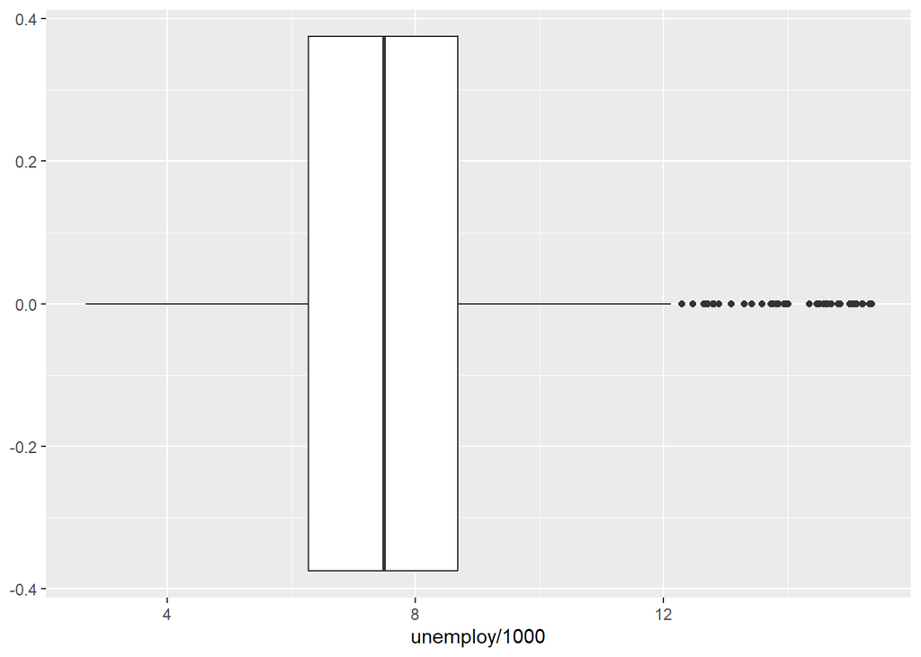

```r
# salva o gráfico em um objeto
boxplot_exploratorio <-
  # ggplot() cria um sistema de coordenadas vazio
  ggplot(economics, aes(x = unemploy/1000)) +
  # adiciona um boxplot
  geom_boxplot()

# exibe o gráfico
boxplot_exploratorio
```

## 2.16 Boxplot Exploratório

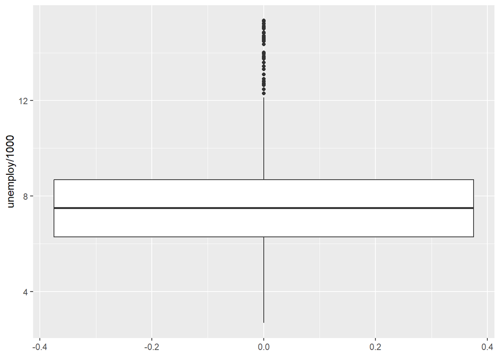

```r
# salva o gráfico em um objeto
boxplot_exploratorio_flip <-
  # ggplot() cria um sistema de coordenadas vazio
  ggplot(economics, aes(x = unemploy/1000)) +
  # adiciona um boxplot
  geom_boxplot() +
  # inverte os eixos
  coord_flip()

# exibe o gráfico
boxplot_exploratorio_flip
```

## 2.17 Boxplot para Publicação

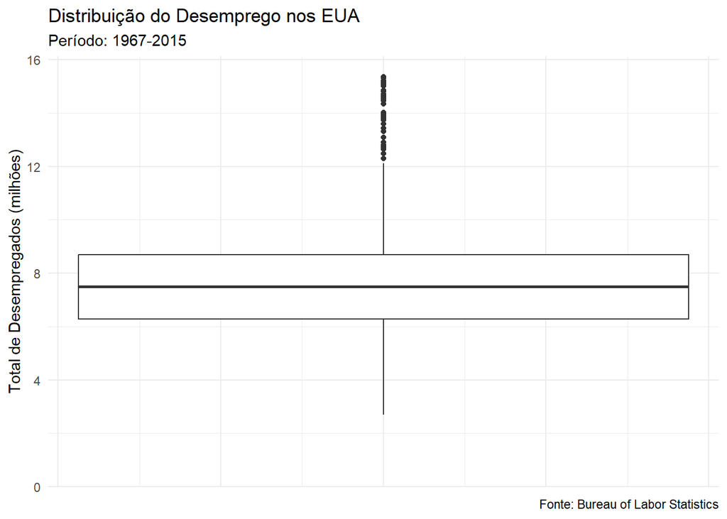

```r
# salva o gráfico em um objeto
boxplot_publicacao <-
  # ggplot() cria um sistema de coordenadas vazio
  ggplot(economics, aes(x = unemploy/1000)) +
  # adiciona um boxplot
  geom_boxplot() +
  # inverte os eixos
  coord_flip() +
  # adiciona zero no eixo X
  scale_x_continuous(limits = c(0, NA), expand = expansion(mult = c(0, 0.05))) +
  # adiciona título, subtítulo, rótulos dos eixos e fonte
  labs(
    title = "Distribuição do Desemprego nos EUA",
    subtitle = "Período: 1967-2015",
    x = "Total de Desempregados (milhões)",
    y = NULL, # remove o rótulo do eixo Y
    caption = "Fonte: Bureau of Labor Statistics"
  ) +
  # define o tema do gráfico
  theme_minimal() +
  # remove os rótulos do eixo X e as marcas do eixo X
  theme(
    axis.text.x = element_blank(),    # remove os rótulos do eixo X
    axis.ticks.x = element_blank()    # remove as marcas do eixo X
  )

# exibe o gráfico
boxplot_publicacao
```

## 2.18 Boxplot Comparativo

- Boxplots são úteis para **comparar a distribuição** de uma variável numérica entre diferentes grupos, sendo o grupo uma variável categórica.
- Esse gráfico permite identificar diferenças na tendência central, variabilidade, simetria/assimetria e presença de outliers entre os grupos, valores possíveis de uma variável categórica.

## 2.19 Boxplot Comparativo Exploratório

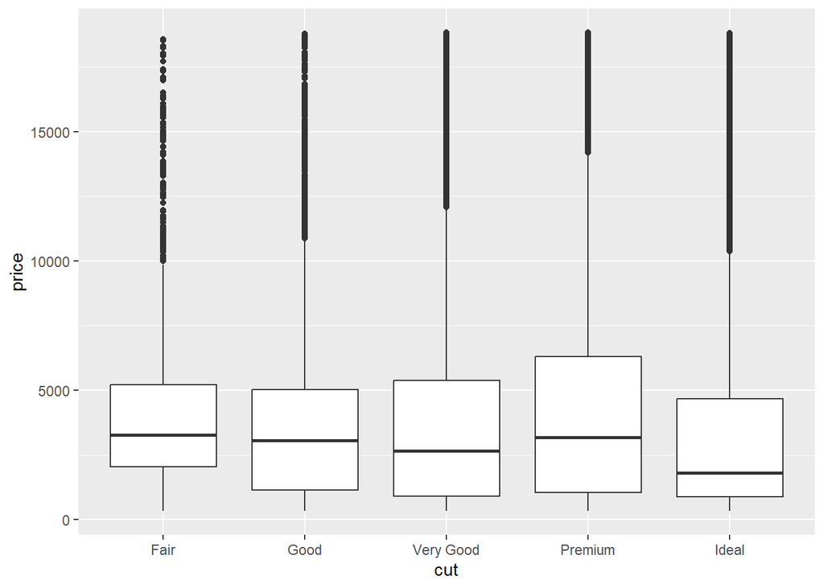

```r
# salva o gráfico em um objeto
boxplot_comparativo_exploratorio <-
  # ggplot() cria um sistema de coordenadas vazio
  ggplot(diamonds, aes(x = cut, y = price)) +
  # adiciona um boxplot
  geom_boxplot()

# exibe o gráfico
boxplot_comparativo_exploratorio
```

## 2.20 Análise do Boxplot Exploratório

Análise na Escala Original

- A variável `price` apresenta uma distribuição fortemente assimétrica positiva (assimétria à direita), para todos os níveis de qualidade do corte (`cut`), com presença de muitos outliers.
- Tipicamente, a distribuição de preços de bens e serviços em geral tende a ser assimétrica à direita, com a maioria dos preços concentrados em torno de valores mais baixos, enquanto alguns poucos preços são muito altos, o que é o caso dos diamantes.
- Esta forte assimetria à direita torna difícil a visualização e interpretação dos dados para comparar os preços dos diamantes por qualidade do corte (`cut`), pois a presença de outliers distorce a análise, dificultando a identificação de padrões e tendências.
- Esse é um caso típico para aplicação de uma transformação logarítmica, que pode ajudar a reduzir a assimetria e melhorar a visualização e interpretação dos dados.

## 2.21 Boxplot Comparativo - Transformação Logarítmica

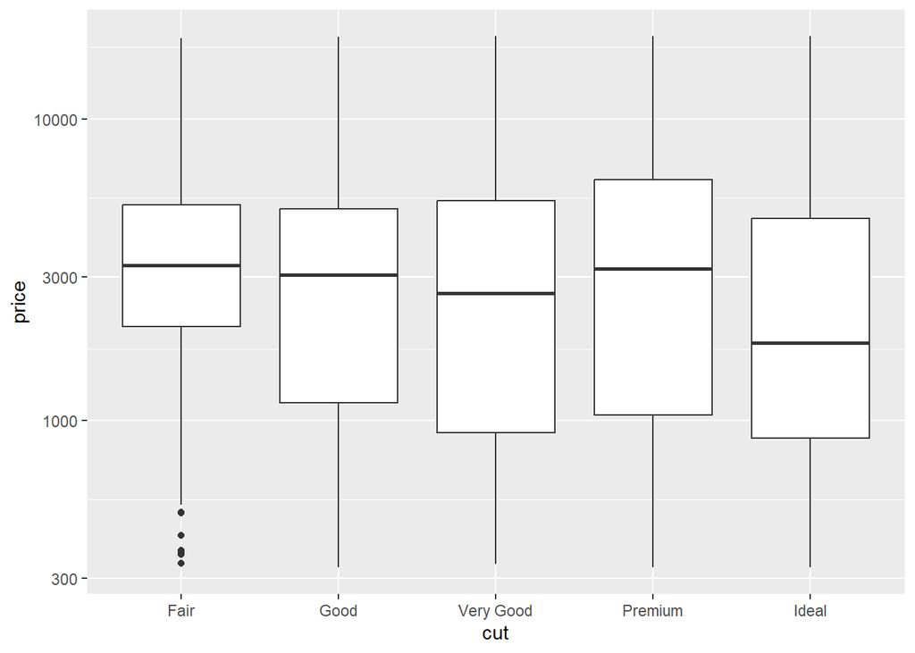

```r
# salva o gráfico em um objeto
boxplot_comparativo_exploratorio <-
  # ggplot() cria um sistema de coordenadas vazio
  ggplot(diamonds, aes(x = cut, y = price)) +
  # adiciona um boxplot
  geom_boxplot() +
  # aplica a escala logarítmica no eixo Y
  scale_y_log10()

# exibe o gráfico
boxplot_comparativo_exploratorio
```

## 2.22 Análise dos Dados na Escala Logarítmica

- **Simetria**: A transformação logarítmica tornou as distribuições mais simétricas e comparáveis, reduzindo o efeito de valores extremos.
- **Medianas**: Surpreendentemente, os preços medianos são similares entre as qualidades de corte, com diamantes `Ideal` apresentando preço mediano ligeiramente inferior.
- **Variabilidade**: A dispersão dos preços é aproximadamente homogênea entre os grupos, exceto para `Fair` que apresenta:
  - Menor variabilidade geral
  - Outliers inferiores indicando diamantes atipicamente baratos
- **Interpretação Cuidadosa**: Este padrão contra-intuitivo sugere que:
  - Outros fatores (peso, clareza, cor) podem estar confundindo a relação corte-preço
  - Diamantes com corte superior podem ter características compensatórias (menor tamanho?)
  - É essencial realizar uma análise multivariada antes de conclusões definitivas
- **Lição Estatística**: Este exemplo ilustra a importância de não basear decisões em análises envolvendo apenas um par de varia’vei quando múltiplas variáveis interagem.

## 2.23 Boxplot Comparativo para Publicação

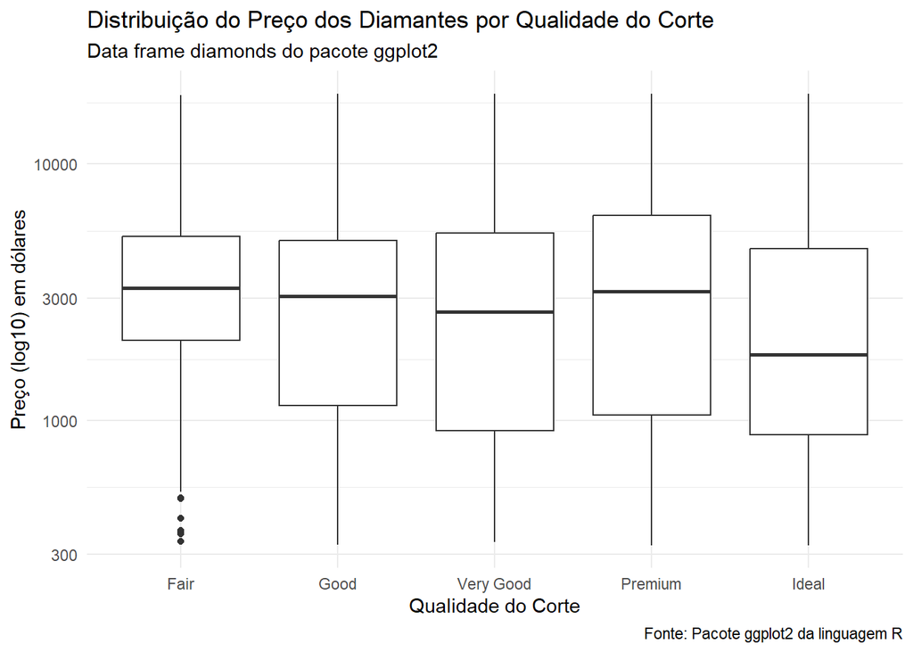

```r
# salva o gráfico em um objeto
boxplot_comparativo_publicacao <-
  # ggplot() cria um sistema de coordenadas vazio
  ggplot(diamonds, aes(x = cut, y = price)) +
  # adiciona um boxplot
  geom_boxplot() +
  # aplica a escala logarítmica no eixo Y
  scale_y_log10() +
  # adiciona título, subtítulo, rótulos dos eixos e fonte
  labs(
    title = "Distribuição do Preço dos Diamantes por Qualidade do Corte",
    subtitle = "Data frame diamonds do pacote ggplot2",
    x = "Qualidade do Corte",
    y = "Preço (log10) em dólares",
    caption = "Fonte: Pacote ggplot2 da linguagem R"
  ) +
  # define o tema do gráfico
  theme_minimal()

# exibe o gráfico
boxplot_comparativo_publicacao
```

## 2.24 Exercício

Prática com ggplot2 usando a data frame `diamonds`

**Parte 1 - Visualizando a variável `price`**

- Histograma (use a regra de Sturges para número de classes)
- Gráfico de densidade empírica
- Histograma + densidade sobreposta
- Boxplot

**Parte 2 - Análise comparativa**

- Crie boxplots de `price` por `clarity`
- Aplique transformação log10 para melhor visualização
- Compare os padrões entre as categorias

**Parte 3 - Análise descritiva**

- Analise o histograma + densidade da Parte 1
- Siga as diretrizes apresentadas em aula
- Comente sobre forma, centro, dispersão e outliers

**Requisitos:**

- Todos os gráficos devem ter títulos e rótulos apropriados
- Customização visual é opcional (exploratório vs. publicação)

**Dica:** A distribuição de `price` é assimétrica. Experimente visualizar também `log10(price)` para comparar interpretações nas duas escalas.

# 3 Gráfico com Qualidade de Publicação

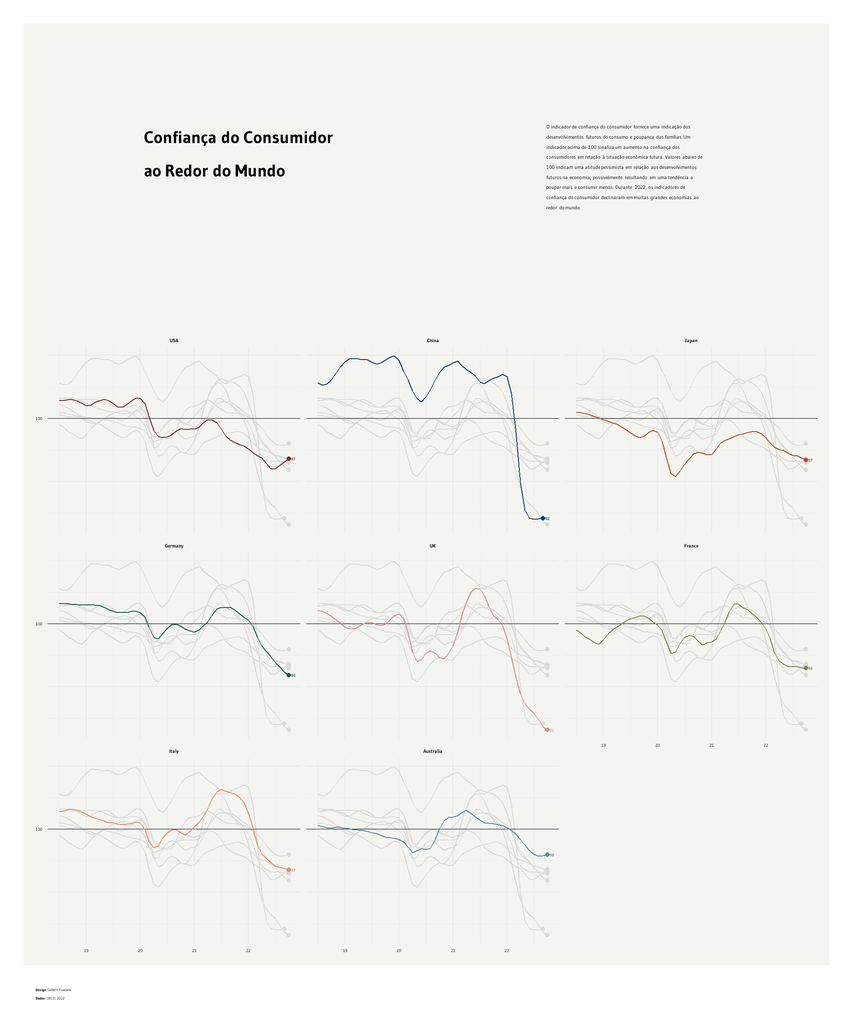

# 4 Recursos Adicionais

Para aprofundar seus conhecimentos em visualização de dados com ggplot2:

- [Documentação oficial do ggplot2](https://ggplot2.tidyverse.org/)
- [Data Visualization with ggplot2 Cheat Sheet](https://rstudio.com/wp-content/uploads/2015/03/ggplot2-cheatsheet.pdf)
- Livro: “ggplot2: Elegant Graphics for Data Analysis” por Hadley Wickham